# Aberration detection methods using the surveillance package

## What is an aberration?

When performing random number generation we use a ‘seed’ to ensure we can reproduce the results

Generate a time series of cases, with 5 years of weekly data (5*52 time points). The average number of cases is 5

```
##   t cases
## 1 1     4
## 2 2     7
## 3 3     4
## 4 4     8
## 5 5     9
## 6 6     2
```

Plot the time series of cases

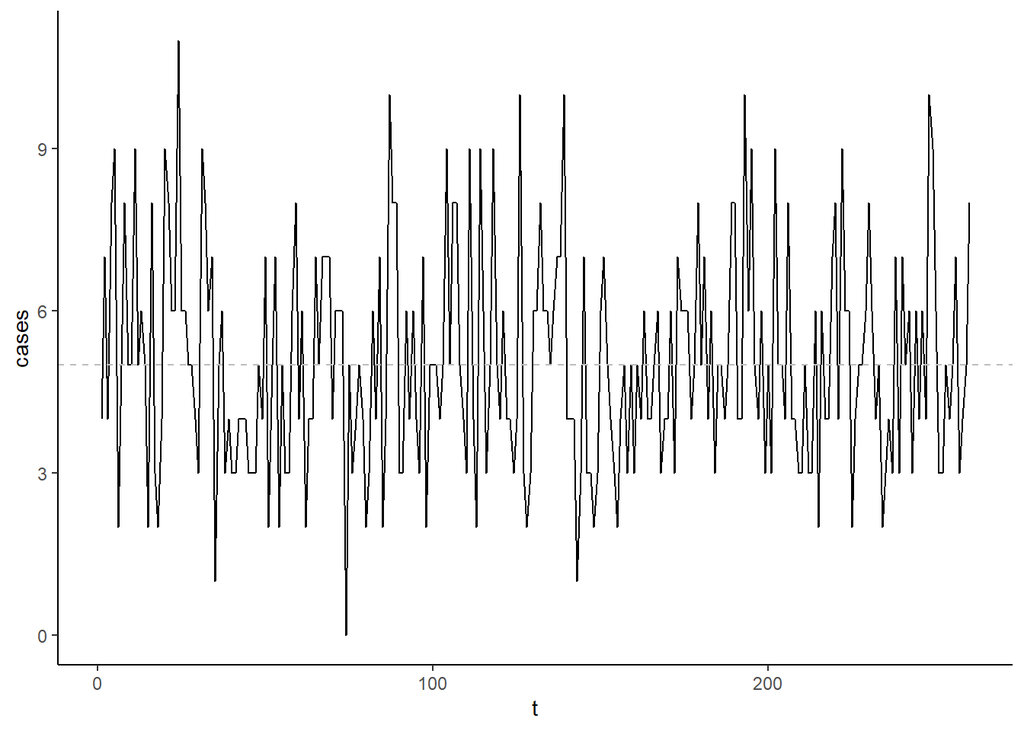

We can see that there are some weeks when cases are above the average, and some cases below the average. And it even looks (by eye) like there might be some stretches where severla weeks in a row are above average. These number are *randomly generated*: the spikes in cases are real, but there is actually no shift in the underlying ‘dynamics’ of the system. There might be nothing out the ordinary to investigate (though some of these spikes might be due to actual clusters). We would want to have a way to say whether a particular week or series of weeks is *abnormal*. In other words, has there been a shift in the underlying dynamics?

### Setting a threshold

The simplest way to set a threshold in an uncomplicated situation like this would be to do something like flag weeks where the number of cases is a certain amount above average. This is sometimes done by calculating the standard deviation of the observed cases and setting a multiple of this as our threshold. in our example, we can see that several weeks are above the threshold during the 5 years of observation. Depending on what disease we are monitoring, this might be too sensitive (as none of these are real aberrations), or not sensitive enough.

Define a threshold

#Plot estimates

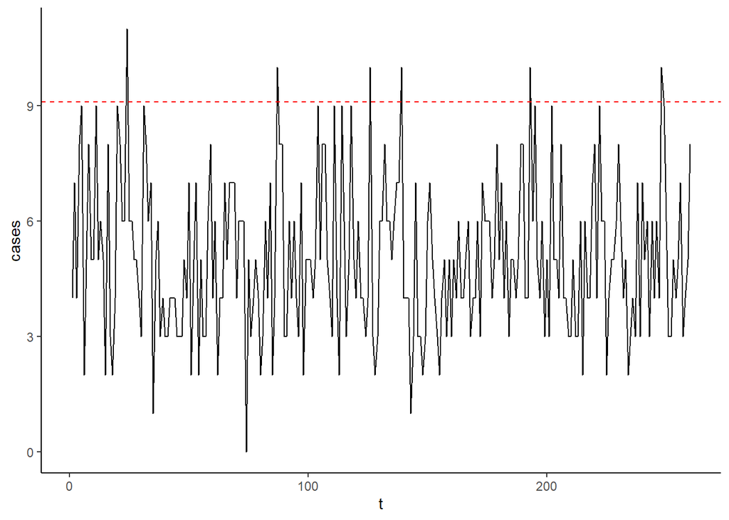

### Why this is an oversimplification

Often the data are more complicated than this. We should be using the correct distribution for rare count data (Poisson or negative binomial) when estimating the threshold. We also might need to adjust for seasonality, or trends in the data. And we might want to detect if several weeks in a row are higher than typical. That is where the algorithms in the surveillance package come in handy.

## Introduction to the Surveillance package

The surveillance package in R has a number of commonly-used aberration detection algorithms. These include some very simple algorithms (historical limits method–ie algo.cdc), as well as some highly sophisticated tools (hidden markov models, geospatial models) We will go through the analysis of some data on *Salmonella agona* from the UK (1990-1995) that is included with the package. We will also go through some examples laid out in Salmon et al., JSS

## Setting up your data to use with the surveillance package

Import the data provided with the surveillance package

```r
head(ds1)
```

```
##         date cases
## 1 1990-01-01     1
## 2 1990-01-08     0
## 3 1990-01-15     5
## 4 1990-01-22     2
## 5 1990-01-29     1
## 6 1990-02-05     2
```

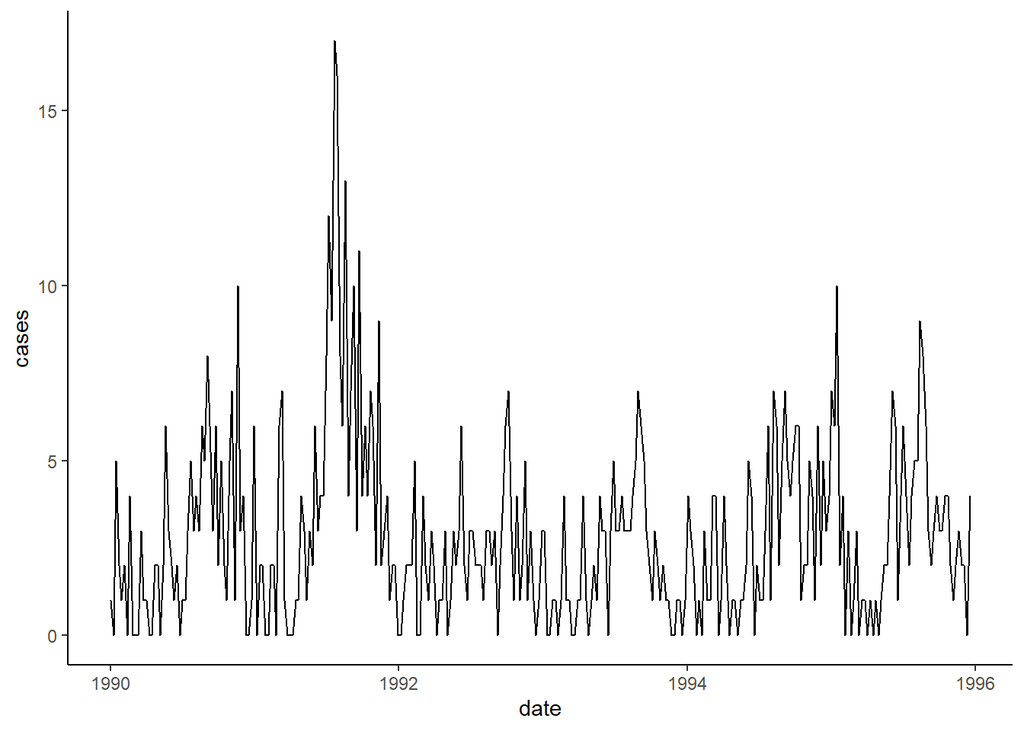

### Historical limits method

This is a simple method used in some CDC reports of routinely-reported diseases. The method was first described by Stroup et al (Statistics in Medicine 1989). It takes the value in the current week, and adds it to data from the previous 3 weeks to create a 4 week period. The algorithm then compares this against the corresponding 4 week period from the previous 5 years.

On the positive side, this is a simple, intuitive way to calculate a threshold. And it inherently adjusts for seasonality (because we are only comparing to the same time of year in previous seasons). On the downside, we need at least 5 years of historical data. And there is no way to adjust for trends in the data or to downweight past epidemics.

m: how many time points on either side to use as reference (typical is 1) b: number of years to go back in time m=1, b=5 will give 15 reference data points

Shiny applications not supported in static R Markdown documents

## Farrington method

Many public health agencies use variations of an algorithm developed by Farrington, where we are testing whether the observed number of cases at a particular time point are above an epidemic threshold.

This method has several advantages: 1. Tests for and adjusts for trend automatically 2. Iterative process that downweights influence of past epidemics (increasing chances of detecting future epidemics) 3. Like the Historical limits method, this method deals with seasonality by only taking values from the same time of year when setting a threshold. 4. Designed for count data and doesn’t make assumptions about the data being normally distributed; this is more appropriate for sparse data

*What happens if you don’t down-weight past epidemics?*

```r
FarringtonApp(ds=ds1, datevar='date', casevar='cases')
```

Shiny applications not supported in static R Markdown documents

## CUSUM approaches

All of the methods discussed so far evaluate whether the number of cases at a specific time point exceed an epidemic threshold. However, we often interested in seeing if there has been a change in the underlying risk the shows up in multiple consecutive time points. Methods that evaluate the CUmulative SUM (CUSUM) methods are designd to do this and are often more robust and ensitivte to accumulated changes.

There are many different CUSUM-type algorithms. We will use one called glrnb. This allows for seasonal and trend adjustment. It works well with count data.

If you specify season=T or trend=T, it fits a trend to data before the evaluation period. Here we hold the first year of data out to allow for training of the seasonality component

### Here is an alternative algorithm for seasonal CUSUM

Shiny applications not supported in static R Markdown documents

## Getting into the weeds of coding

The analyses above use some wrapper functions to make things easier. If you wanted to do this yourself without the shiny app, you would do the following:

### Step 1: Convert your data to a format the surveillance package can recognize

```
## List of 8
##  $ week          : int [1:312] 1 2 3 4 5 6 7 8 9 10 ...
##  $ observed      : int [1:312, 1] 1 0 5 2 1 2 0 4 0 0 ...
##   ..- attr(*, "dimnames")=List of 2
##   .. ..$ : NULL
##   .. ..$ : chr "observed"
##  $ state         : num [1:312, 1] 0 0 0 0 0 0 0 0 0 0 ...
##   ..- attr(*, "dimnames")=List of 2
##   .. ..$ : NULL
##   .. ..$ : chr "observed"
##  $ start         : num [1:2] 1990 1
##  $ freq          : num 52
##  $ neighbourhood : logi [1, 1] NA
##  $ populationFrac: num [1:312, 1] 1 1 1 1 1 1 1 1 1 1 ...
##  $ epochAsDate   : logi FALSE
##  - attr(*, "class")= chr "disProg"
```

### Step 2: Call the algorithm of interest

### Step 3: Plot the output

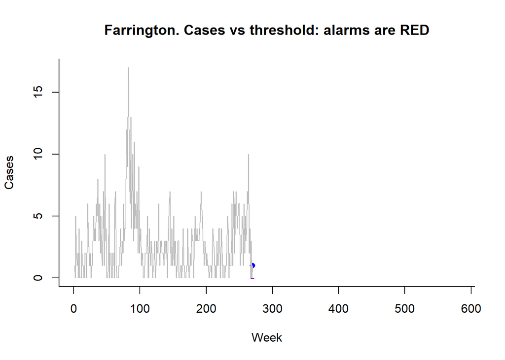